# Análisis de Asistencia

Carolina Maria Wundes, Nicolás Dino Ferme

6/21/2019

## Acciones de Cercanía

### DGCPAR, Subsecretaría de Comunicación, Gobierno de la Ciudad de Buenos Aires

El área de Cercanía que depende de la Dirección General de Comunicación Participativa del Gobierno de la ciudad está a cargo de iniciativas que conforman una estrategia integral cuyo propósito es acercar la gestión gubernamental a los vecinos. El objetivo es que cada acción de gobierno sea una respuesta real a las necesidades de los vecinos. Llevar adelante una gestión que se corresponda con la identidad de la ciudad, aumentando el sentido de pertenencia, compromiso y vinculación del ciudadano con el gobierno. Es uno de los valores centrales de la gestión de Horacio Rodríguez Larreta. Por esta razón, el Jefe de Gobierno invierte más del 40 % del tiempo de su agenda para estar cerca de los vecinos.

Las iniciativas que forman parte de Cercanía son:

- After con Jovenes (AFJ)
- Asado de obra (ADO)
- Café con comerciantes (CCC)
- Café con empleados de Gobierno (CEG)
- Café con referentes culturales (CRC)
- Café con vecinAs (CCVA)
- Café con vecinos (CCVO)
- Café Mujeres Mentoreadas (CMM)
- Experiencias (EXP)
- Instagram en vivo (IGV)
- Mano a mano (MAM)
- Relevancias (REL)
- Reunión cámaras de Seguridad (RCS)
- Reuniones con empleados de Gobierno (REG)
- Reuniones con vecinAs (RVA)
- Reuniones con vecinos (RVO)

En el siguiente análisis se veran los datos provenientes de las acciones realizadas a partir de la semana 1 del 2019 hasta la semana 24, estas se realizan en todos los barrios de la Ciudad de Buenos Aires, salvo en Puerto Madero. Se analizaran los asistentes finales a las acciones en relación a los inscriptos, para luego compararlo con el barrio donde se realizar las acciones y la época del año. Los datos de los eventos se tomaron directamente de la Dirección General de Comunicación Participativa mientras que los datos geográficos sobre buenos aires se tomaron de https://data.buenosaires.gob.ar.

Es importante el análisis para ver el compromiso y la voluntad participativa de los ciudadanos y como esta se va transformando de barrio en barrio así como también a traves del tiempo. Nos brinda una primera aproximación al nivel de compromiso de la ciudadanía en relación las acciones de participación ciudadana.

En primera instancia instalamos los paquetes necesarios para realizar el análisis, tidyverse, sf y cargamos las librerías.

## Datos de Acciones de Cercanía

```r
Eventos <- read.csv("C:/Users/Caro/Desktop/Curso Ciencia de Datos/Cercania/Cercania Final Entrega/Eventos.csv")
```

Inspeccionamos el archivo

```r
summary(Eventos)
```

```
##      SEMANA      TIPO.DE.REUNION  FUNCIONARIO          BARRIO
##  Min.   : 1.00   RVO    :137     HRL    :138   RECOLETA   : 26
##  1st Qu.: 8.00   CCVO   : 95     DS     : 73   PALERMO    : 19
##  Median :14.00   CEG    : 11     JM     : 41   SAN NICOLAS: 10
##  Mean   :13.29   REL    :  9     MAYEP  : 12   BALVANERA  :  9
##  3rd Qu.:19.00   EXP    :  7     CESBA  :  9   MONSERRAT  :  9
##  Max.   :24.00   IGV    :  6     FM     :  9   RETIRO     :  9
##                  (Other): 30     (Other): 13   (Other)    :213
##    INSCRIPTOS       ASISTENTES        AUSENTES         ALCANCE
##  Min.   :   0.0   Min.   :  0.00   Min.   :-502.0   Min.   :      0
##  1st Qu.:   0.0   1st Qu.:  7.00   1st Qu.:  -7.0   1st Qu.:  11575
##  Median :  68.0   Median : 13.00   Median :  21.0   Median :  41581
##  Mean   : 194.9   Mean   : 54.59   Mean   : 140.3   Mean   : 112219
##  3rd Qu.: 315.5   3rd Qu.: 66.50   3rd Qu.: 221.5   3rd Qu.: 128496
##  Max.   :3526.0   Max.   :584.00   Max.   :3510.0   Max.   :1889695
##
```

Vemos la variables que contiene

```r
names(Eventos)
```

```
## [1] "SEMANA"          "TIPO.DE.REUNION" "FUNCIONARIO"     "BARRIO"
## [5] "INSCRIPTOS"      "ASISTENTES"      "AUSENTES"        "ALCANCE"
```

Graficamos la cantidad y los distintos tipos de reuniones que se realizan por barrio:

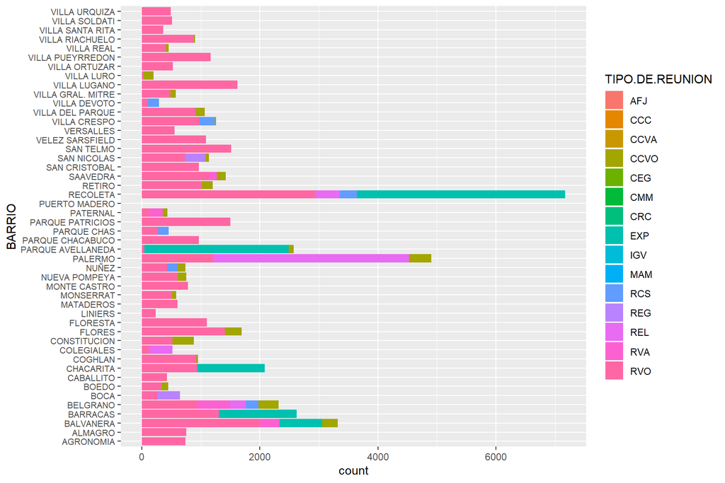

```r
ggplot(Eventos) +
    geom_bar(aes(x = BARRIO, weight = INSCRIPTOS, fill = TIPO.DE.REUNION)) +
    coord_flip() +
    theme(axis.text.y=element_text(size=rel(0.9)))
```

Podemos ver que la mayor cantidad de inscriptos se centran en los barrios de Recoleta y Palermo.

## Ausencias por barrio

### Asistentes en relación a Inscriptos

Para comenzar nuestro análisis mapearemos las ausencias por barrio. La variable que geolocaliza el evento es la de (“BARRIO”), por lo cual vamos a utilizarla para visualizar la información geográficamente. Para esto cargamos un archivo georeferenciado con los barrios de la Ciudad Autónoma de Buenos Aires

```r
barrios <- st_read('https://data.buenosaires.gob.ar/dataset/19/resource/1c3d185b-fdc9-474b-b41b-9bd960a3806e/download/barrios.geojson')
```

Para lograr mapear las ausencias acumuladas por barrio, agruparemos la información mediante el comando de suma para poder compararla.

```r
Eventos_por_barrio_sum <- Eventos %>%
    group_by(BARRIO) %>%
    summarise(INSCRIPTOS = sum(INSCRIPTOS),
              ASISTENTES = sum(ASISTENTES),
              AUSENTES = sum(AUSENTES),
              ALCANCE = sum(ALCANCE))
```

Ya tenemos dos datasets con una columna en común que los relaciona (“BARRIO”) permitiendo cruzar los datos. Queremos conservar todas las observaciones del dataset geográfico, agregando los datos contenidos en el dataset de Eventos_por_barrio_sum en donde la variable BARRIO sea la misma.

```r
Eventos_por_barrio_acumulado <- barrios %>% left_join(Eventos_por_barrio_sum)
```

Mapeamos los ausentes acumulados por barrio:

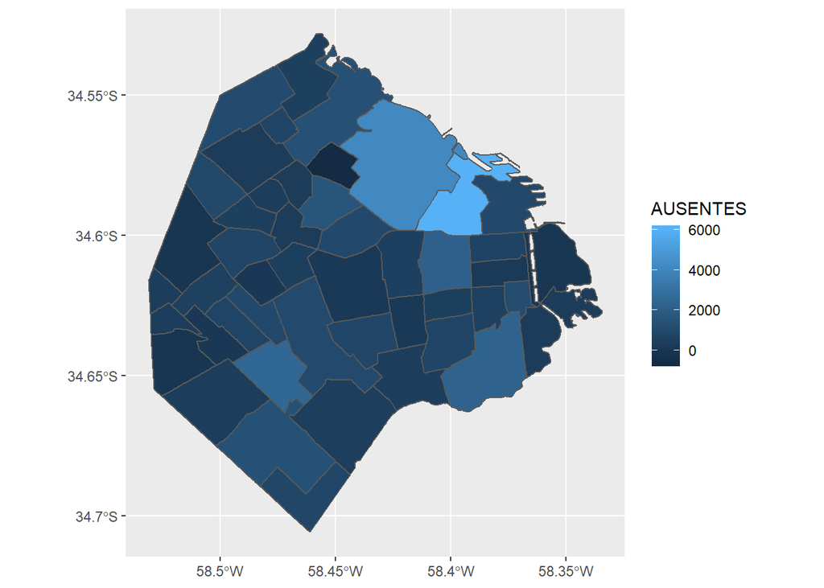

```r
ggplot() + geom_sf(data = Eventos_por_barrio_acumulado, aes(fill = AUSENTES))
```

Nuevamente podemos ver que la mayor cantidad de ausentes se centran en Recoleta y Palermo. Para realizar un análisis menos sesgado en base a la cantidad de inscriptos a las acciones, utilizaremos la mediana de ausencias en cada barrio.

```r
Eventos_por_barrio_med <- Eventos %>%
    group_by(BARRIO) %>%
    summarise(INSCRIPTOS = sum(INSCRIPTOS),
              ASISTENTES = sum(ASISTENTES),
              AUSENTES = median(AUSENTES),
              ALCANCE = median(ALCANCE))
```

Ya tenemos nuestro nuevo datasets con una columna en común que los relaciona (“BARRIO”) permitiendo cruzar los datos. Queremos conservar todas las observaciones del dataset geográfico, agregando los datos contenidos en el dataset de Eventos_por_barrio_med en donde la variable BARRIO sea la misma.

```r
Eventos_por_barrio_mediana <- barrios %>% left_join(Eventos_por_barrio_med)
```

Mapeamos la mediana de ausentes por barrio:

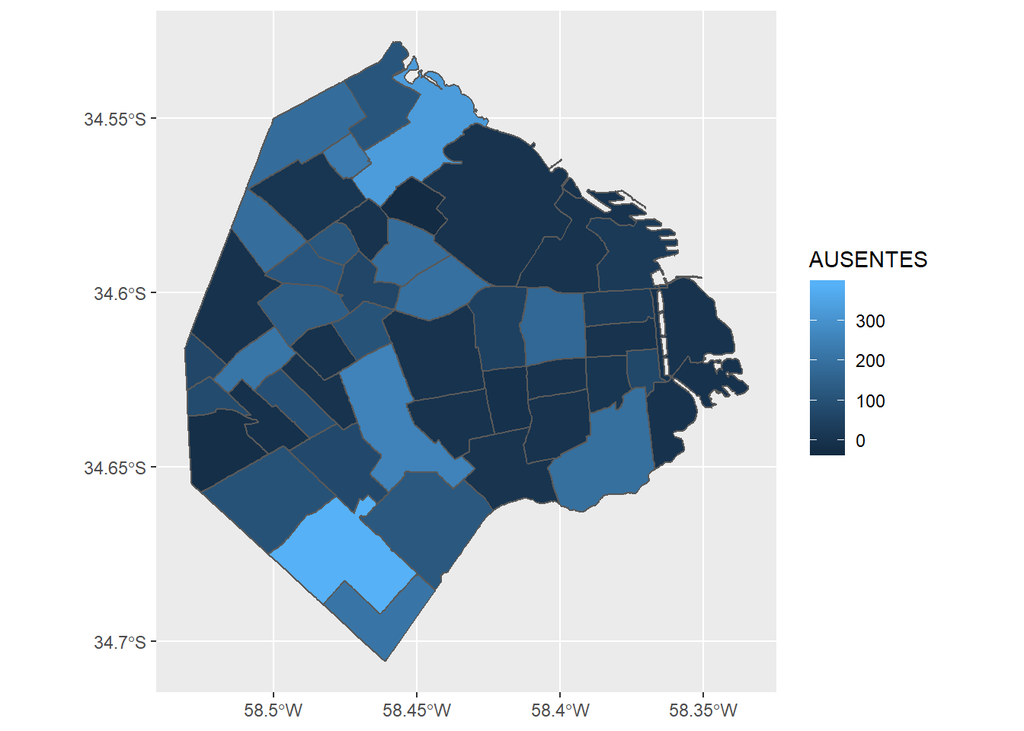

```r
ggplot() + geom_sf(data = Eventos_por_barrio_mediana, aes(fill = AUSENTES))
```

Podemos ver que los resultados son completamente distintos.

Veamos los datos resultantes para ver cuales son los barrios con mayor nivel de ausentismo.

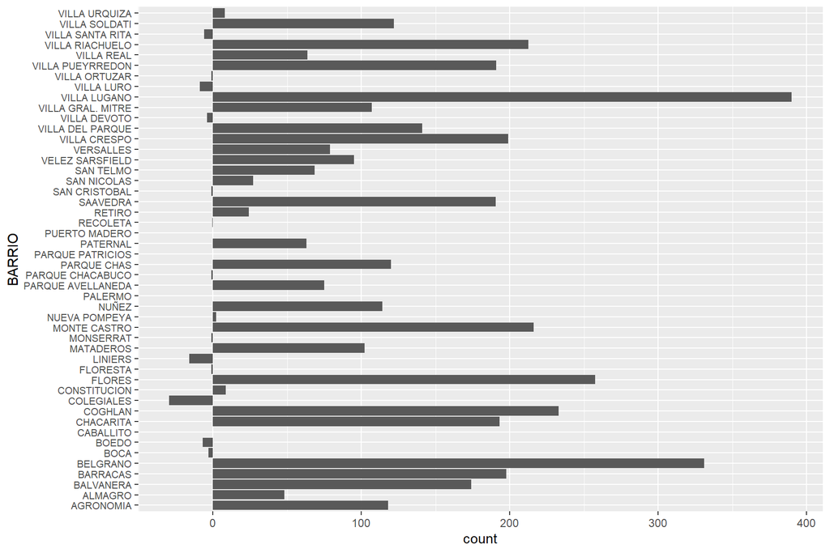

```r
ggplot(Eventos_por_barrio_mediana) +
    geom_bar(aes(x = BARRIO, weight = AUSENTES)) +
    coord_flip() +
    theme(axis.text.y=element_text(size=rel(0.9)))
```

nota: los valores negativos pertenecen a inidividuos que se asistieron a la acción sin inscripción

Los barrios con mayor asistencia fueron Colegiales, Liniers, Villa Luro, Boedo y Villa Santa Rita

## Ausencias por semana del año

### Asistentes en relación a Inscriptos

Procedemos a analizar la asistencia que se registra en las acciones de Cercanía a lo largo del tiempo. Tomando el período de tiempo de los eventos analizados, desde la semana 1 del 2019 hasta la 24. Realizamos agregación por SEMANA de los datos, en este caso, basándonos en el análisis anterior, tomando la mediana de los ausentes.

```r
Eventos_por_semana <- Eventos %>%
    group_by(SEMANA) %>%
    summarise(INSCRIPTOS = sum(INSCRIPTOS),
              ASISTENTES = sum(ASISTENTES),
              AUSENTES = median(AUSENTES),
              ALCANCE = median(ALCANCE))
```

Veamos como se relaciona el paso del tiempo (variable explicativa) con las ausencias a las acciones de Cercanía.

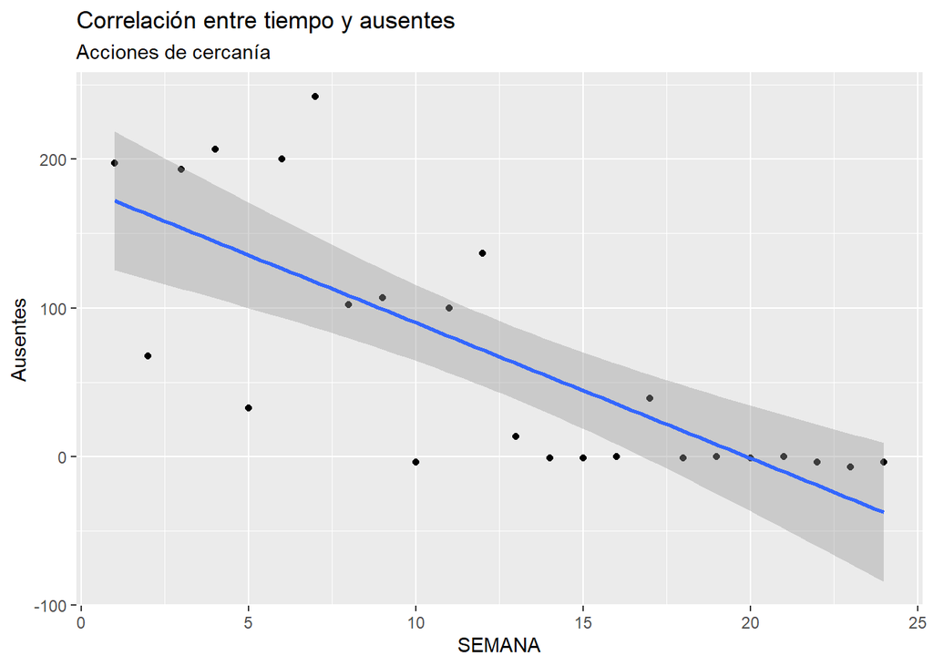

```r
ggplot(data = Eventos_por_semana) +
    geom_point(aes(x = SEMANA, y = AUSENTES)) +
    labs(title = "Correlación entre tiempo y ausentes",
         subtitle = "Acciones de cercanía",
         y = "Ausentes") +
    geom_smooth(aes(x = SEMANA, y = AUSENTES), method = "lm")
```

nota: los valores negativos provienen de individuos que asistieron a las acciones sin haberse inscripto.

```r
cor(Eventos_por_semana$SEMANA, Eventos_por_semana$AUSENTES)
```

```
## [1] -0.7564532
```

- Semana 7: 11 de febrero al 17 de febrero
- Semana 12: 18 de marzo al 24 de marzo
- Semana 17: 22 de abril al 28 de abril

En los tres casos las semanas poseen un feriado o están conectadas a uno, en el primer caso, coincide con carnaval y coincide con comienzo de la segunda quincena de febrero (época de vacaciones más económicas), en el segundo caso con el 24 de Marzo, Día Nacional de la Memoria por la Verdad y la Justicia, y justo la semana del 22 al 28 de Abril se encontró en medio de semana santa y el día del trabajador 1ero de mayo.